# Case Assignment 4 - Flu Analysis

Daniel Clark

6/23/2020

```r
library(tswge)
library(doParallel)
registerDoParallel(cores=16)
library(nnfor)
library(tswge)
library(forecast)
library(vars)
flu_tidy = read.csv("https://raw.githubusercontent.com/dhyanshah/MS7333_QTW/master/Case8/flu_tidy.csv")

summary(flu_tidy)
```

```
##       year           week         week.year         Positive
##  Min.   :2017   Min.   : 1.00   Min.   : 1.202   Min.   :   24.0
##  1st Qu.:2017   1st Qu.:12.00   1st Qu.:12.202   1st Qu.:  358.5
##  Median :2018   Median :23.00   Median :23.202   Median : 1601.0
##  Mean   :2018   Mean   :24.64   Mean   :24.839   Mean   : 6568.2
##  3rd Qu.:2019   3rd Qu.:37.50   3rd Qu.:37.702   3rd Qu.:11047.0
##  Max.   :2020   Max.   :52.00   Max.   :52.202   Max.   :30771.0
##     Negative
##  Min.   : 4440
##  1st Qu.:10738
##  Median :22117
##  Mean   :24692
##  3rd Qu.:35908
##  Max.   :67857
```

For this study, we are choosing to forecast flu cases in the United States region. The data covers from the first week of 2017 through to the 23rd week of 2020, or rather through the start of June, 2020.

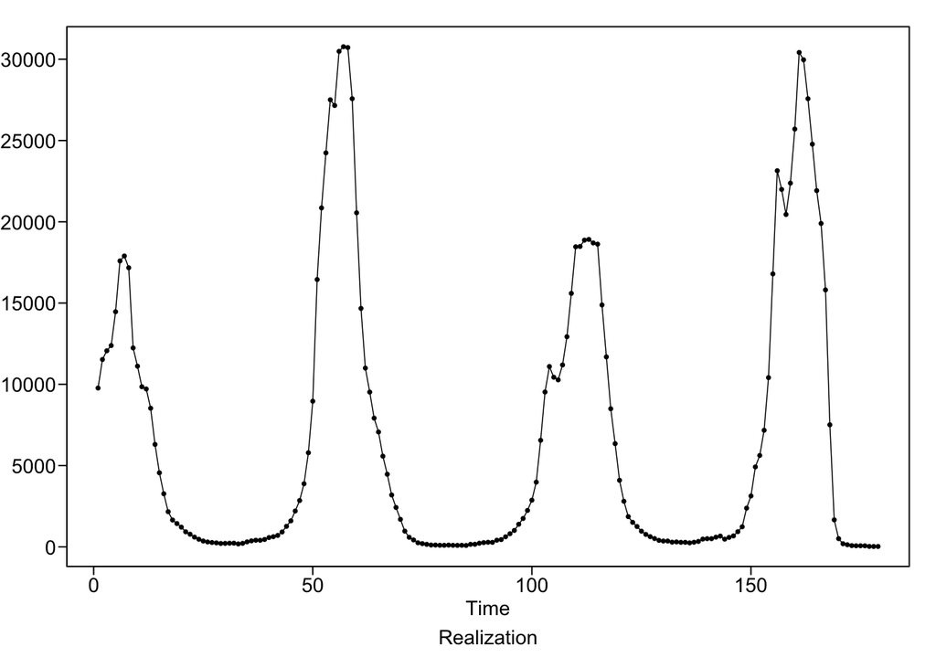

```r
plotts.wge(flu_tidy$Positive)
```

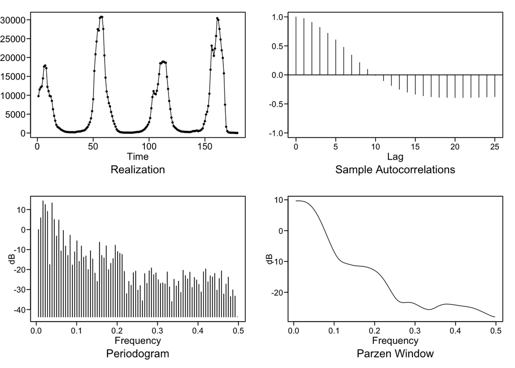

[output not shown]

[output cut: 46 more lines]

```r
plotts.sample.wge(flu_tidy$Positive)
```

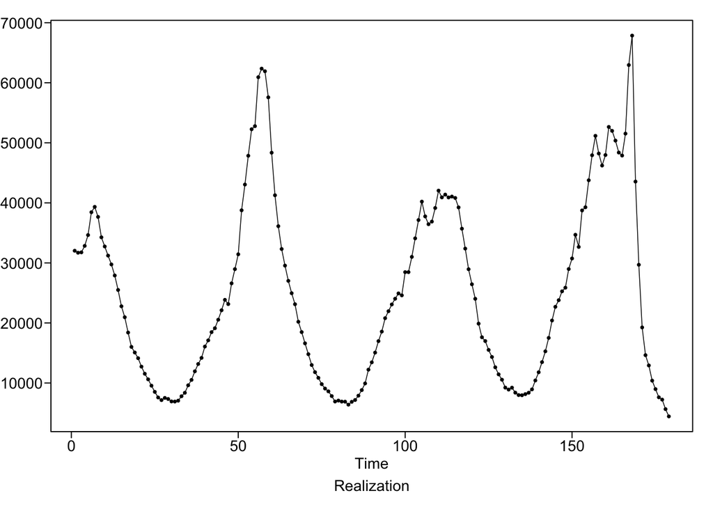

```r
plotts.wge(flu_tidy$Negative)
```

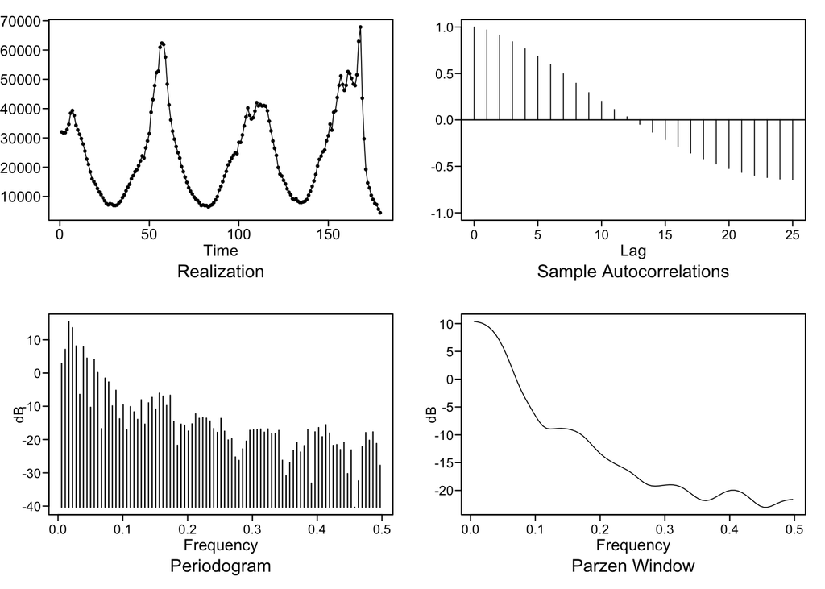

[output not shown]

[output cut: 42 more lines]

```r
plotts.sample.wge(flu_tidy$Negative)
```

Here we can see that there is a stationary pattern emerging from both our instances of positive cases and negative tests, it appears that they are happening consistently during the winter season each year, which makes sense as that time frame typically correlates with flu season each year.

Both Spectral Densities suggest there’s a wandering behavior outside of the spikes which are not super apparent visually, but we can see a hint of them at around .15 and .4 on both positive and negative plots.

```r
aic5.wge(flu_tidy$Positive, p = 0:15, q = 0:15)
```

[output not shown]

```
##        p    q        aic
## 113    7    0   14.16232
## 40     2    7   14.16889
## 129    8    0   14.17020
## 114    7    1   14.17086
## 38     2    5   14.17674
```

```r
aic5.wge(flu_tidy$Negative, p = 0:15, q = 0:15)
```

[output not shown]

```
##        p    q        aic
## 102    6    5   15.78323
## 193   12    0   15.81752
## 104    6    7   15.81909
## 194   12    1   15.82814
## 209   13    0   15.82815
```

Considering, visually, we have a large seasonality associated with our positive tests, so let’s see if we can reduce the impact of it.

```r
seasdif = artrans.wge(flu_tidy$Positive, c(rep(0,51),1))
```

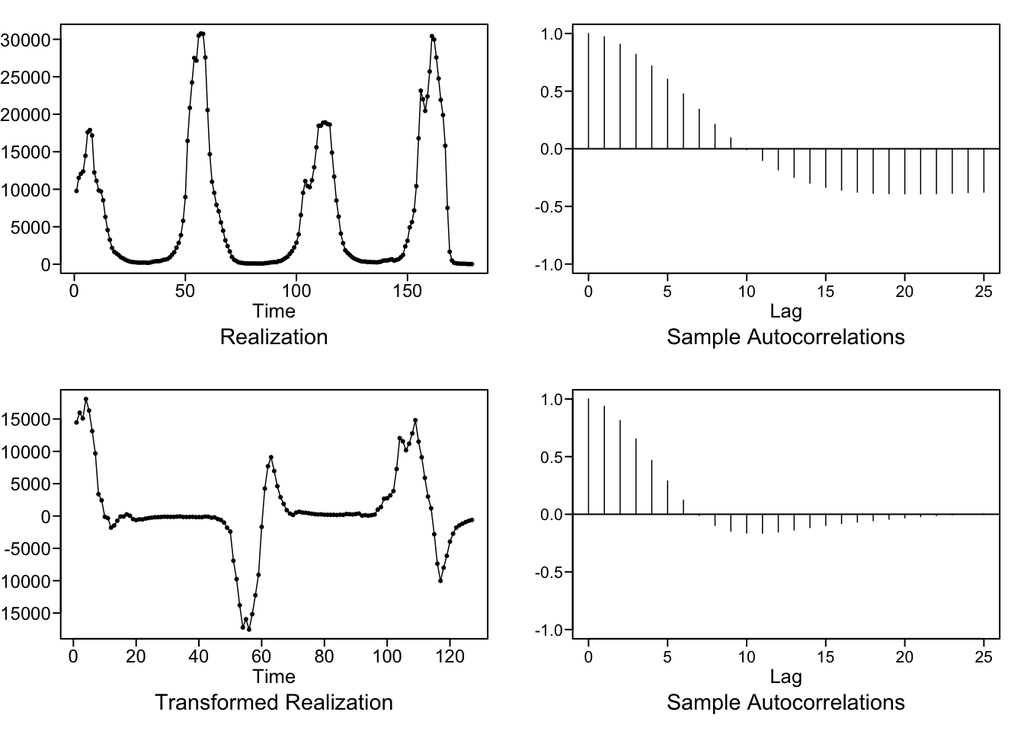

```r
parzen.wge(seasdif)
```

[output not shown]

```r
aic5.wge(seasdif)
```

```
## ---------WORKING... PLEASE WAIT...
##
##
## Five Smallest Values of  aic
```

```
##       p    q        aic
## 18    5    2   14.38587
## 15    4    2   14.38907
## 17    5    1   14.40323
## 10    3    0   14.42681
## 8     2    1   14.43218
```

[figure not shown]

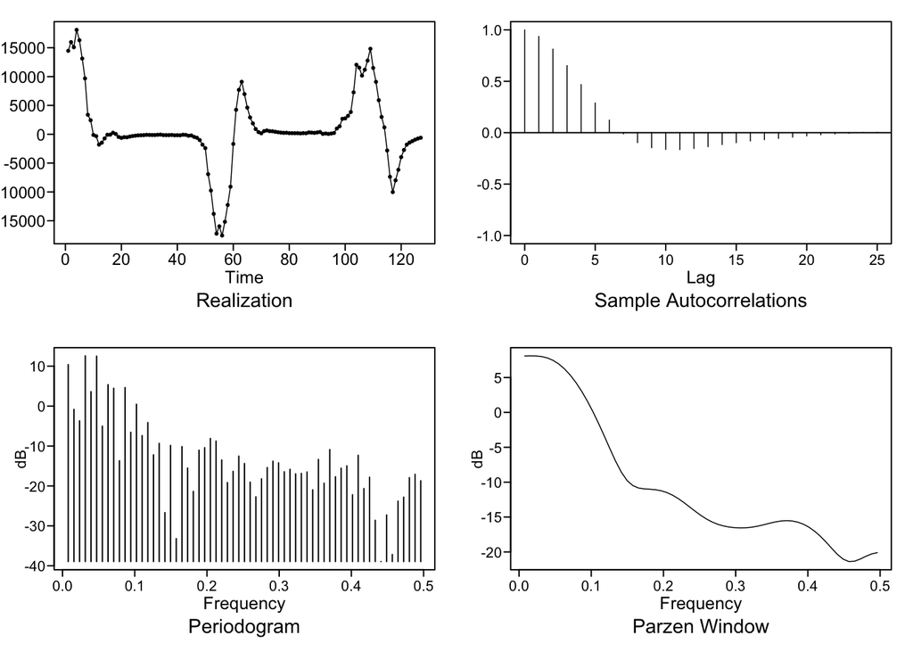

[output not shown]

[output cut: 33 more lines]

```r
plotts.sample.wge(seasdif)
```

Accounting for the weekly seasonaility by running differencing on 52 weeks, we can see that we have a smoothe spectral density and a realization that relies less on on the 4 seasonal factors in the winter and shows more of the change in demand year over year.

```r
flufore1 = fore.aruma.wge(flu_tidy$Positive, s = 52, n.ahead = 45, lastn = TRUE)
```

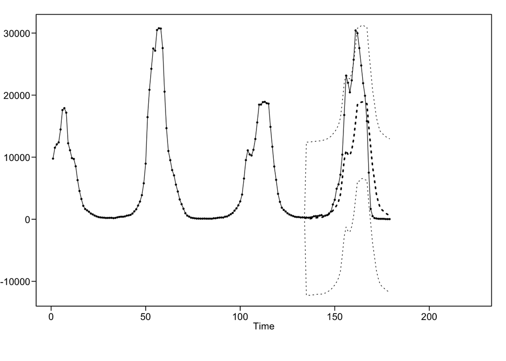

```r
ase1 = mean(((flufore1$f - flu_tidy$Positive[135:179])))
ase1
```

```
## [1] -1788.444
```

```r
flufore2 = fore.aruma.wge(seasdif, s = 52, n.ahead = 45, lastn = TRUE)
```

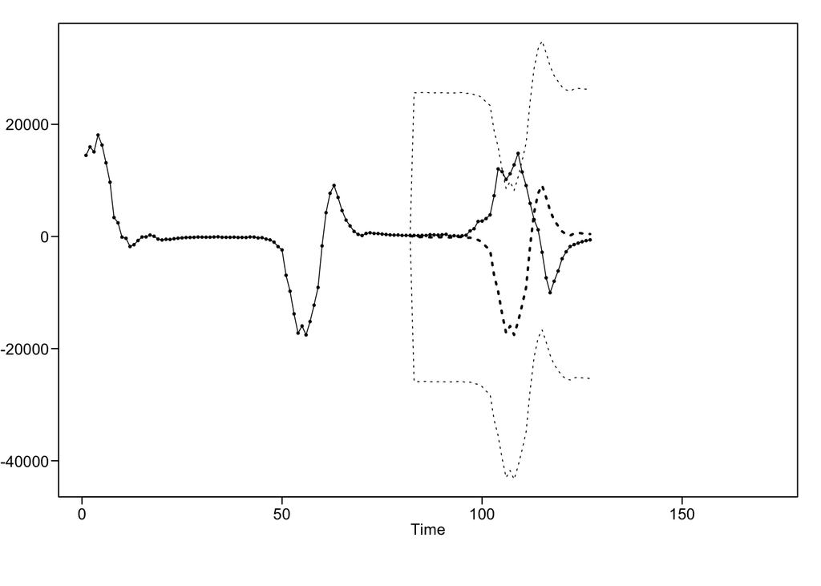

```r
ase2 = mean(((flufore2$f - flu_tidy$Positive[135:179])))
ase2
```

```
## [1] -9753.844
```

Lets try a nueral model.

```r
flu_train = ts(flu_tidy$Positive[1:153], start = c(2017,1),frequency = 52)
nonflu_train = ts(flu_tidy$Negative[1:153], start = c(2017,1),frequency = 52)
flu_test = ts(flu_tidy$Positive[154:179], start = c(2019,49),frequency = 52)
nonflu_test = ts(flu_tidy$Negative[154:179], start = c(2019,49),frequency = 52)
#set.seed(255)
fit.mlp= mlp(flu_train, lags=1:52, hd.auto.type="valid",hd.max=10)
fit.mlp
```

```
## MLP fit with 1 hidden node and 20 repetitions.
## Series modelled in differences: D1D52.
## Univariate lags: (1,7,52)
## Forecast combined using the median operator.
## MSE: 612629.2456.
```

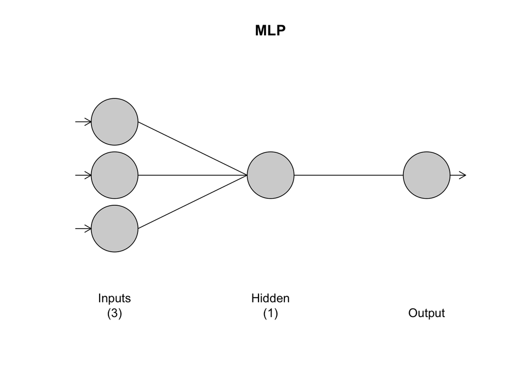

```r
plot(fit.mlp)
```

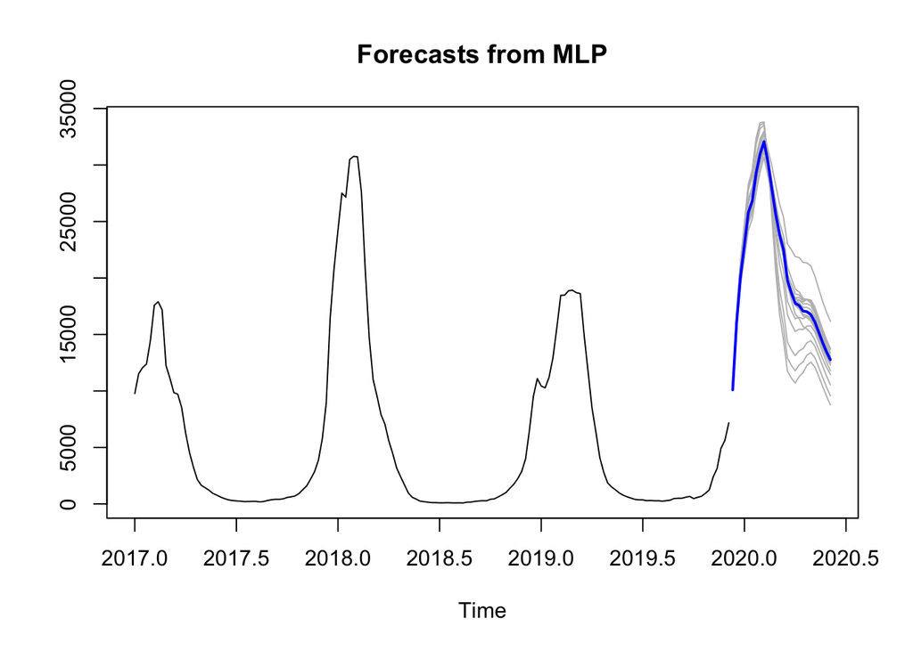

```r
h=26
frc <- forecast(fit.mlp,h=h)
plot(frc)
```

```r
frc
```

```
##          Point Forecast
## 2019.942       10101.00
## 2019.962       16026.02
## 2019.981       20156.21
## 2020.000       22920.82
## 2020.019       25776.96
## 2020.038       26816.34
## 2020.058       29290.76
## 2020.077       30955.60
## 2020.096       32075.20
## 2020.115       30319.83
## 2020.135       27942.05
## 2020.154       25670.13
## 2020.173       23824.90
## 2020.192       22507.83
## 2020.212       19812.16
## 2020.231       18688.74
## 2020.250       17760.42
## 2020.269       17564.21
## 2020.288       17072.70
## 2020.308       17010.12
## 2020.327       16752.60
## 2020.346       16119.87
## 2020.365       15219.94
## 2020.385       14294.00
## 2020.404       13466.51
## 2020.423       12761.64
```

```r
ASE.mlp = mean((flu_test-frc$mean)^2)
ASE.mlp
```

```
## [1] 141184263
```

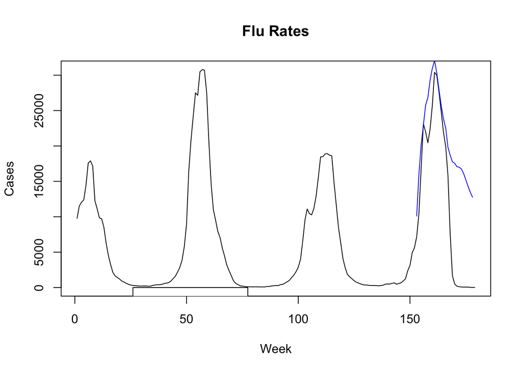

```r
# Plotting Forecast vs actual for MLP
plot(flu_tidy$Positive, type = "l",
     main='Flu Rates',
     xlab="Week"
     ,ylab="Cases")
lines(seq(153,178,1),frc$mean,col = "blue")
#axis(1, at=1:37, labels=seq(1936,1972,1),las=2)
legend(26, 3, legend=c("MLP Forecast", 'Actual'),
       col=c("green", 'black'), lty=1, cex=0.9)
```